# Introduction and Objective of the Study:

The goal of this Exploratory Data Analysis (EDA) is to identify which factors influence the number of car seat units sold (Sales) at each store location. The dataset contains both numerical predictors (prices, income, age, etc.) and categorical predictors (Shelving Quality, Urban vs Rural, US vs Non-US). The analysis follows a fully structured approach combining visual exploration, statistical tests, and regression modelling.

The workflow is as follows:

**1. Data Check and Cleaning 2. Exploratory Visualisations and Descriptive Analysis >> 3. Correlation and Association Analysis >> 4. Statistical Tests >> 5. Regression Analysis >> 6. Summary of Interpretation and Insights**

Each step of the workflow is detailed below.

## Importing Libraries

```python
import pandas as pd
import matplotlib.pyplot as plt
import numpy as np
import seaborn as sns
from scipy import stats
import statsmodels.api as sm
from statsmodels.stats.outliers_influence import variance_inflation_factor
from scipy.stats import ttest_ind
from scipy.stats import ttest_rel
import warnings
from statsmodels.formula.api import ols
```

```python
from bokeh.layouts import row
from bokeh.models import ColumnDataSource, DataTable, TableColumn
from bokeh.plotting import figure, show
from bokeh.layouts import gridplot
import holoviews as hv
```

## Step 1. Data Check and Cleaning

The dataset is generally clean, with 400 records and only 4 instances containing at least one missing value. Even though this represents just 1% of the dataset and the missing values are spread across different variables, we have chosen not to keep or impute them - rather delete the records so there will not be any issue while doing ANOVA or Regression.

The dataset contains two main of variable types:  
Numeric: Sales, CompPrice, Income, Advertising, Price, Age (continuous); Population and Education (discrete)  
Categorical: ShelveLoc (Shelving Quality), Urban (Yes/No), US (Yes/No)

```python
# loading the dataset
df_main = pd.read_excel("CarSeats.xlsx")
```

```python
# List of variables and their data type
df_main.info()
```

```
<class 'pandas.core.frame.DataFrame'>
RangeIndex: 400 entries, 0 to 399
Data columns (total 11 columns):
 #   Column       Non-Null Count  Dtype
---  ------       --------------  -----
 0   Sales        399 non-null    float64
 1   CompPrice    399 non-null    float64
 2   Income       399 non-null    float64
 3   Advertising  400 non-null    int64
 4   Population   400 non-null    int64
 5   Price        400 non-null    int64
 6   ShelveLoc    400 non-null    object
 7   Age          400 non-null    int64
 8   Education    400 non-null    int64
 9   Urban        399 non-null    object
 10  US           400 non-null    object
dtypes: float64(3), int64(5), object(3)
memory usage: 34.5+ KB
```

```python
# A snippet into the first 5 rows of the dataset
df_main.head()
```

|  | Sales | CompPrice | Income | Advertising | Population | Price | ShelveLoc | Age | Education | Urban | US |
| --- | --- | --- | --- | --- | --- | --- | --- | --- | --- | --- | --- |
| 0 | 9.50 | 138.0 | 73.0 | 11 | 276 | 120 | Bad | 42 | 17 | Yes | Yes |
| 1 | 11.22 | 111.0 | 48.0 | 16 | 260 | 83 | Good | 65 | 10 | Yes | Yes |
| 2 | 10.06 | 113.0 | 35.0 | 10 | 269 | 80 | Medium | 59 | 12 | Yes | Yes |
| 3 | 7.40 | 117.0 | 100.0 | 4 | 466 | 97 | Medium | 55 | 14 | Yes | Yes |
| 4 | 4.15 | 141.0 | 64.0 | 3 | 340 | 128 | Bad | 38 | 13 | Yes | No |

```python
# A quick sum of the missing values in each variable
df_main.isnull().sum()
```

```
Sales          1
CompPrice      1
Income         1
Advertising    0
Population     0
Price          0
ShelveLoc      0
Age            0
Education      0
Urban          1
US             0
dtype: int64
```

```python
# The records containing the null values
df_main[df_main[['Sales', 'CompPrice', 'Income', 'Urban']].isna().any(axis=1)]
```

|  | Sales | CompPrice | Income | Advertising | Population | Price | ShelveLoc | Age | Education | Urban | US |
| --- | --- | --- | --- | --- | --- | --- | --- | --- | --- | --- | --- |
| 19 | 8.73 | 129.0 | NaN | 16 | 58 | 121 | Medium | 69 | 12 | Yes | Yes |
| 22 | 5.08 | NaN | 46.0 | 6 | 497 | 138 | Medium | 42 | 13 | Yes | No |
| 51 | NaN | 121.0 | 90.0 | 0 | 150 | 108 | Bad | 75 | 16 | Yes | No |
| 62 | 1.82 | 139.0 | 45.0 | 0 | 146 | 133 | Bad | 77 | 17 | NaN | Yes |

```python
# Deleting the records with null values to avoid errors in ANOVA or other statistical analyses
df = df_main.replace([np.inf, -np.inf], np.nan).dropna()
df.isna().sum()
```

```
Sales          0
CompPrice      0
Income         0
Advertising    0
Population     0
Price          0
ShelveLoc      0
Age            0
Education      0
Urban          0
US             0
dtype: int64
```

## Step 2. Exploratory Visualisations and Descriptive Analysis

For categorical values - first we checked the unique values of each variables and its count before plotting them in a bar chart. They are not evenly distributed as the charts show. Exploratory Visulations in this section lead the way to further exploration in the Correlation and Association section.

### Numeric Variables: Distributions and Outliers

```python
# A basic summary statistics of the numerical variables of the dataset
df.describe()
```

|  | Sales | CompPrice | Income | Advertising | Population | Price | Age | Education |
| --- | --- | --- | --- | --- | --- | --- | --- | --- |
| count | 396.000000 | 396.000000 | 396.00000 | 396.000000 | 396.000000 | 396.000000 | 396.000000 | 396.000000 |
| mean | 7.521414 | 124.931818 | 68.70202 | 6.646465 | 265.366162 | 115.702020 | 53.196970 | 13.893939 |
| std | 2.816309 | 15.392350 | 28.05604 | 6.650498 | 147.056382 | 23.749368 | 16.172068 | 2.624879 |
| min | 0.000000 | 77.000000 | 21.00000 | 0.000000 | 10.000000 | 24.000000 | 25.000000 | 10.000000 |
| 25% | 5.457500 | 115.000000 | 42.00000 | 0.000000 | 139.000000 | 100.000000 | 39.000000 | 12.000000 |
| 50% | 7.495000 | 124.500000 | 69.00000 | 5.000000 | 274.000000 | 117.000000 | 54.000000 | 14.000000 |
| 75% | 9.322500 | 135.000000 | 91.00000 | 12.000000 | 398.500000 | 131.000000 | 65.250000 | 16.000000 |
| max | 16.270000 | 175.000000 | 120.00000 | 29.000000 | 509.000000 | 191.000000 | 80.000000 | 18.000000 |

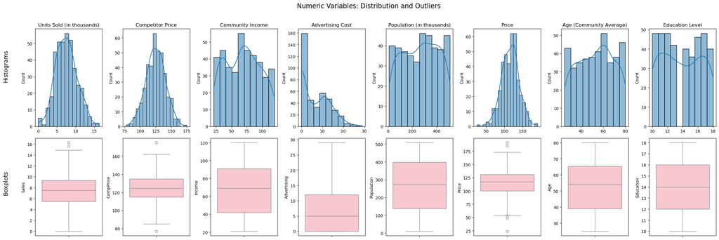

```python
#list of numeric columns
num_cols = ['Sales','CompPrice','Income','Advertising','Population','Price','Age','Education']

#Column Labels
ncol_names = ['Units Sold (in thousands)','Competitor Price','Community Income','Advertising Cost','Population (in thousands)','Price','Age (Community Average)','Education Level']

# 2 rows - for distribution and histogram, 8 columns for 8 variables
fig, axes = plt.subplots(2, 8, figsize=(24, 8))

for i, (col, name) in enumerate(zip(num_cols, ncol_names)):
    # Histogram in first row
    sns.histplot(df[col], kde=True, ax=axes[0, i])
    axes[0, i].set_title(f'{name}')
    axes[0, i].set_xlabel('')    # Removing x-axis titles to declutter the charts

    # Boxplot in second row
    sns.boxplot(y=df[col], ax=axes[1, i], color='pink')

# Adding a single title for the whole grid
fig.suptitle('Numeric Variables: Distribution and Outliers', fontsize=16, y=1.02)

# Adding row labels (y-position adjusted)
fig.text(-0.02, 0.75, 'Histograms', fontsize=14, va='center', rotation = 'vertical')
fig.text(-0.02, 0.25, 'Boxplots', fontsize=14, va='center', rotation='vertical')

plt.tight_layout()
plt.show()
```

### Categorical Variables: Distributions

```python
from bokeh.io import output_notebook
output_notebook()

cat_cols = ['ShelveLoc', 'Urban', 'US']  # categorical columns
ccol_names = ['Shelf Quality', 'Urban Store', 'US Store']  # corresponding display names

plots = []
tables = []

for col, display_name in zip(cat_cols, ccol_names):
    vc = df[col].value_counts(dropna=False)
    values = [str(v) for v in vc.index.tolist()]
    counts = vc.values

    src = ColumnDataSource(data=dict(
        value=values,
        count=counts
    ))

    # Bar chart
    p = figure(
        x_range=values,
        height=250, width=300,
        title=f"{display_name}",
        toolbar_location=None
    )
    p.vbar(x="value", top="count", width=0.8, source=src)
    p.xaxis.major_label_orientation = 0  # no rotation

    # Table
    columns = [
        TableColumn(field="value", title="Value"),
        TableColumn(field="count", title="Count"),
    ]
    tbl = DataTable(source=src, columns=columns, width=300, height=350)

    plots.append(p)
    tables.append(tbl)

# Arrange first row with all charts, second row with all tables
grid = gridplot([plots, tables])
show(grid)
```

[output not shown]

Loading BokehJS ...

**Key Takeaways:** Most of the products have the Shelf Position of Medium quality. The stores are mostly situated in urban area and almost 2/3rd of the shops are situated in the US.

```python
med_income = df['Income'].median()

subset1 = df[(df['Income'] >= med_income) & (df['Urban'] == 'Yes')]
subset1.describe()
```

|  | Sales | CompPrice | Income | Advertising | Population | Price | Age | Education |
| --- | --- | --- | --- | --- | --- | --- | --- | --- |
| count | 147.000000 | 147.000000 | 147.000000 | 147.000000 | 147.000000 | 147.000000 | 147.000000 | 147.000000 |
| mean | 7.824286 | 123.632653 | 91.292517 | 6.741497 | 262.863946 | 113.605442 | 54.176871 | 13.680272 |
| std | 2.900506 | 16.499930 | 14.928235 | 6.570053 | 149.172587 | 24.653366 | 15.384880 | 2.671479 |
| min | 0.530000 | 77.000000 | 69.000000 | 0.000000 | 13.000000 | 24.000000 | 25.000000 | 10.000000 |
| 25% | 5.865000 | 114.000000 | 80.000000 | 0.000000 | 135.500000 | 98.000000 | 42.000000 | 11.000000 |
| 50% | 7.540000 | 123.000000 | 89.000000 | 5.000000 | 262.000000 | 116.000000 | 56.000000 | 13.000000 |
| 75% | 10.055000 | 135.000000 | 102.000000 | 12.000000 | 403.000000 | 129.500000 | 65.500000 | 16.000000 |
| max | 14.370000 | 161.000000 | 120.000000 | 25.000000 | 508.000000 | 166.000000 | 80.000000 | 18.000000 |

## Step 3: Correlation and Association Analysis

From the distribution patterns observed in the previous section, it appears that several variables may be correlated and could influence sales. In this section, we explore these relationships using visualizations, a Pearson correlation matrix for numeric variables, and Chi-square tests for categorical variables. Furthermore, based on the insights generated from the exploratory visualisations, we delved deeper and look for any correlation between the categorical attributes of the store and the number of sales.

### Correlation Matrix for Numerical Variables

#### Are there any correlation between the sales and the other numerical attributes of the store and the product?

Numerical attributes e.g. competitor price, product price, income of the community, population in the community, etc.

```python
#dataframe with numerical values only
df_n = df.loc[:, df.dtypes != 'object']
df_n.head()
```

|  | Sales | CompPrice | Income | Advertising | Population | Price | Age | Education |
| --- | --- | --- | --- | --- | --- | --- | --- | --- |
| 0 | 9.50 | 138.0 | 73.0 | 11 | 276 | 120 | 42 | 17 |
| 1 | 11.22 | 111.0 | 48.0 | 16 | 260 | 83 | 65 | 10 |
| 2 | 10.06 | 113.0 | 35.0 | 10 | 269 | 80 | 59 | 12 |
| 3 | 7.40 | 117.0 | 100.0 | 4 | 466 | 97 | 55 | 14 |
| 4 | 4.15 | 141.0 | 64.0 | 3 | 340 | 128 | 38 | 13 |

```python
#creating the correlation matrix
correlation_matrix = df_n.corr()
correlation_matrix
```

|  | Sales | CompPrice | Income | Advertising | Population | Price | Age | Education |
| --- | --- | --- | --- | --- | --- | --- | --- | --- |
| Sales | 1.000000 | 0.068760 | 0.149274 | 0.263351 | 0.049909 | -0.444711 | -0.226571 | -0.044222 |
| CompPrice | 0.068760 | 1.000000 | -0.078286 | -0.023582 | -0.094004 | 0.584242 | -0.103866 | 0.023757 |
| Income | 0.149274 | -0.078286 | 1.000000 | 0.058103 | -0.004021 | -0.053003 | -0.006231 | -0.056430 |
| Advertising | 0.263351 | -0.023582 | 0.058103 | 1.000000 | 0.270297 | 0.045301 | -0.001140 | -0.026372 |
| Population | 0.049909 | -0.094004 | -0.004021 | 0.270297 | 1.000000 | -0.014365 | -0.031341 | -0.104712 |
| Price | -0.444711 | 0.584242 | -0.053003 | 0.045301 | -0.014365 | 1.000000 | -0.103558 | 0.011513 |
| Age | -0.226571 | -0.103866 | -0.006231 | -0.001140 | -0.031341 | -0.103558 | 1.000000 | 0.000613 |
| Education | -0.044222 | 0.023757 | -0.056430 | -0.026372 | -0.104712 | 0.011513 | 0.000613 | 1.000000 |

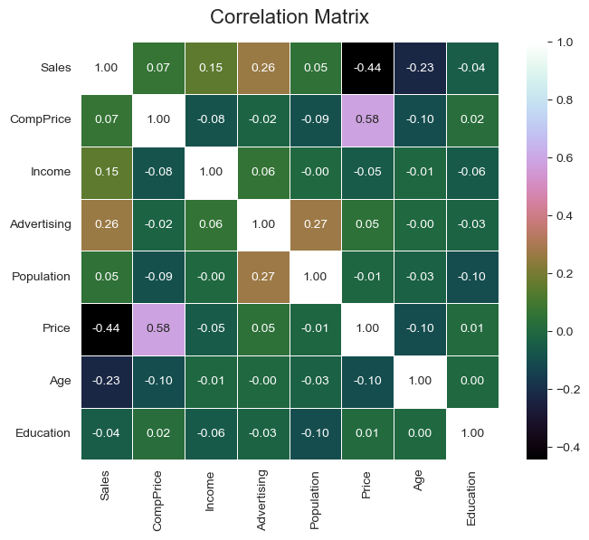

```python
#creating heatmap from the correlation matrix

plt.figure(figsize=(8,6))
sns.set_style("whitegrid")

# Heatmap
sns.heatmap(correlation_matrix, annot=True,  fmt=".2f", cmap="cubehelix", cbar=True, square=True, linewidths=0.5)

plt.title("Correlation Matrix", fontsize=16, pad=15)
plt.show()
```

**Key Takeaways from Correlation Matrix**

Price is the strongest factor negatively affecting sales.

Advertising has some positive effect, while demographic variables (Population, Age, Education) have minimal influence.

#### Are there any correlation between the sales and the store's geopraphical location as well as the car seat's shelf position?

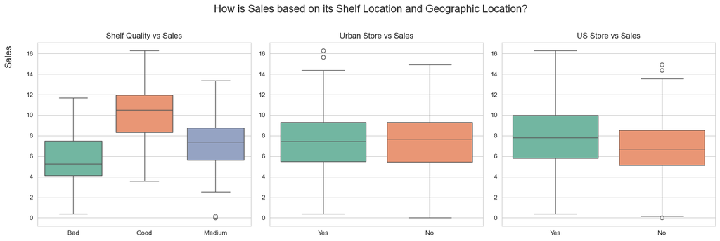

```python
# Getting all categorical columns
cat_cols = [col for col in df.columns if df[col].dtype == 'object']
col_names = ['Shelf Quality', 'Urban Store', 'US Store']

sns.set_style("whitegrid")
palette = "Set2"  # soft colors
# Creating subplots: 1 row, as many columns as categorical variables
fig, axes = plt.subplots(1, len(cat_cols), figsize=(5 * len(cat_cols), 5), squeeze=False)


for i, (col, name) in enumerate(zip(cat_cols, col_names)):
    sns.boxplot(x=col, y='Sales', data=df, ax=axes[0, i], palette = palette)
    axes[0, i].set_title(f"{name} vs Sales")
    axes[0, i].tick_params(axis='x')
    axes[0, i].set_xlabel('') # decluttering by removing axis titles
    axes[0, i].set_ylabel('')

# Adding a single title for the whole grid
fig.suptitle('How is Sales based on its Shelf Location and Geographic Location?', fontsize=16, y=1.02)
# Adding row labels (y-position adjusted)
fig.text(-0.02, 0.75, 'Sales', fontsize=14, va='bottom', rotation = 'vertical')


plt.tight_layout()
plt.show()

warnings.filterwarnings('ignore')
```

**Key Takeaways from Visualisation**

Urban vs Non-Urban: Urban stores are twice as many, with a few very high performers. However, Non-Urban stores show stronger consistency, achieving a similar median sales level despite being fewer.

US vs Non-US: Non-US stores have high outliers, while US stores show a wider sales range overall.

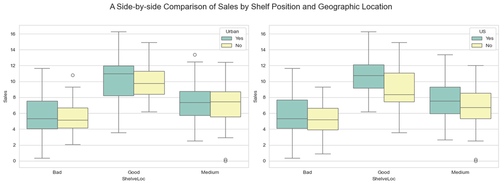

```python
# Set a clean style
sns.set_style("whitegrid")
palette = "Set3"
fig, axes = plt.subplots(1, 2, figsize=(14, 5))

# Plot 1: ShelveLoc × Sales × Urban
sns.boxplot(data=df, x="ShelveLoc", y="Sales", hue="Urban", ax=axes[0], palette = palette)

# Plot 2: ShelveLoc × Sales × US
sns.boxplot(data=df, x="ShelveLoc", y="Sales", hue="US", ax=axes[1], palette = palette)

# Adding a single title for the whole grid
fig.suptitle('A Side-by-side Comparison of Sales by Shelf Position and Geographic Location', fontsize=16, y=1.02)


plt.tight_layout()
plt.show()
```

**Key Takeaways from the charts**

As seen in the previous chart, Urban and non-Urban stores has similiar sales. But, stores in the US has overall higher sales than non-US ones. Some of the stores where the Car Seats are positioned in a Medium quality shelf location has worse sales in the non-urban and non US area. Urban and US stores has better consistency in this regard. But even though there are not many non-US stores - it is worthwhile to mention that non-US markets had greater variability in performance. This variability suggests there may be underlying market differences worth exploring further.

### Chi-square Test

**Shelf Position and Store Location Correlation Statistical Test**

Can we say whether the Shelf position good bad or medium is correlated to whether the store is in the US or in Urban area? We need to do chi-squre test for that. The hypotheses are:

Hypotheis 1

$H_0: $ Shelf position (Good, Medium, Bad) is independent of whether a store is Urban or Non-Urban.  
$H_A: $ Shelf position is dependent on whether a store is Urban or Non-Urban.

Hypothesis 2

$H_0: $ Shelf position (Good, Medium, Bad) is independent of whether a store is in US.  
$H_A: $ Shelf position is dependent on whether a store is in US.

```python
# To test Hypothesis 1, creating contingency table
cont_table1 = pd.crosstab(df['ShelveLoc'], df['Urban'])
cont_table1
```

| Urban ShelveLoc | No | Yes |
| --- | --- | --- |
| Bad | 22 | 72 |
| Good | 28 | 57 |
| Medium | 68 | 149 |

```python
# Performing the test
chi2, p_val, dof, expected = stats.chi2_contingency(cont_table1)
print(f"p-value: {p_val}")
```

```
p-value: 0.28881804548584356
```

```python
# To test Hypothesis 2, creating contingency table
cont_table2 = pd.crosstab(df['ShelveLoc'], df['US'])
cont_table2
```

| US ShelveLoc | No | Yes |
| --- | --- | --- |
| Bad | 33 | 61 |
| Good | 24 | 61 |
| Medium | 83 | 134 |

```python
# Performing the test
chi2, p_val, dof, expected = stats.chi2_contingency(cont_table2)
print(f"p-value: {p_val}")
```

```
p-value: 0.2614665318248534
```

**Key Takeaway from Chi-Square Test**

We failed to reject both the hypotheses. Car Seat's shelf position quality has no significant correlation to the store's location whether US or Urban.

### Anova Test

In the Pearson correlation matrix and chi-square tests, we first examine pairwise relationships: numeric variables with Sales, and categorical variables like Shelf Location with US/Urban. For instance, Price shows a moderate negative correlation with Sales (~ -0.45), while Advertising shows a weak positive correlation (~0.27). Shelf position shows no correlation.

Pearson's correlation and Chi-square are limited because it is pairwise, linear, and cannot test independence between numeric and categorical variables. To address this, we use ANOVA, which allows us to assess the effect of multiple predictors (numeric and categorical) on Sales simultaneously, determine which variables significantly contribute, and compare the magnitude of effects using F-statistics and p-values.

The Hypotheses are:

Hypothesis 1:

$H_0: $ Mean Sales is the same for all Shelf Locations (Good, Medium, Bad)

$H_A: $ Mean Sales differs for at least one Shelf Location

Hypotheses 2.. ..7:

$H_0: $ The predictor has no effect on Sales (coefficient = 0)

$H_A: $ The predictor has a significant effect on Sales (coefficient ≠ 0)

Here the predictors are Price, Advertising Cost, Community Income,Competitor Price,Community Population, Average Age of Community,Community Education Level.

```python
# Linear model with categorical and numeric predictors -
# we are including almost all variables here even though some of their pairwise correlation was low.
model_full = ols('Sales ~ C(ShelveLoc) + C(US) + C(Urban) + Price + Advertising + Income + CompPrice + Population + Age + Education', data=df).fit()
anova = sm.stats.anova_lm(model_full, typ=2)
print(anova)
```

```
                   sum_sq     df            F         PR(>F)
C(ShelveLoc)  1042.304709    2.0   499.614938  1.379996e-107
C(US)            1.382549    1.0     1.325413   2.503392e-01
C(Urban)         1.287569    1.0     1.234358   2.672563e-01
Price         1316.288369    1.0  1261.890744  2.039117e-123
Advertising    121.646993    1.0   116.619745   6.431234e-24
Income          74.536837    1.0    71.456489   5.965347e-16
CompPrice      519.389784    1.0   497.925208   2.520345e-71
Population       0.507686    1.0     0.486706   4.858228e-01
Age            214.409964    1.0   205.549145   1.224529e-37
Education        1.004652    1.0     0.963133   3.270167e-01
Residual       400.553484  384.0          NaN            NaN
```

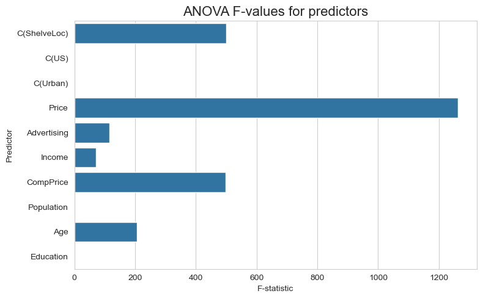

```python
# Preparing ANOVA table for visualisation (excluding residuals)
anova_plot = anova.reset_index().rename(columns={'index':'Variable'})
anova_plot = anova_plot[anova_plot['Variable'] != 'Residual']  # drop residual

plt.figure(figsize=(8,5))
sns.barplot(x='F', y='Variable', data=anova_plot)
plt.title('ANOVA F-values for predictors', fontsize=16)
plt.xlabel('F-statistic')
plt.ylabel('Predictor')
plt.tight_layout()
plt.show()
```

```python
# Confidence Interval. If a predictor's confidence interval does not include 0 the model is significant.
# Even though we got F and p value to measure a predictor's explanation power of variance in the dependendent variable -
# - and p-value to undertand the significance of the F-value I am still calculating the CI
# CI gives us the range of values in which the true effect of the predictor is likely to lie.

print(model_full.conf_int(alpha=0.05))  # 95% CI
```

```
                               0         1
Intercept               4.437511  6.820657
C(ShelveLoc)[T.Good]    4.539635  5.145975
C(ShelveLoc)[T.Medium]  1.697319  2.198791
C(US)[T.Yes]           -0.472631  0.123546
C(Urban)[T.Yes]        -0.096996  0.349032
Price                  -0.100508 -0.089965
Advertising             0.099360  0.143595
Income                  0.012026  0.019315
CompPrice               0.084639  0.100996
Population             -0.000475  0.000997
Age                    -0.052367 -0.039736
Education              -0.058475  0.019536
```

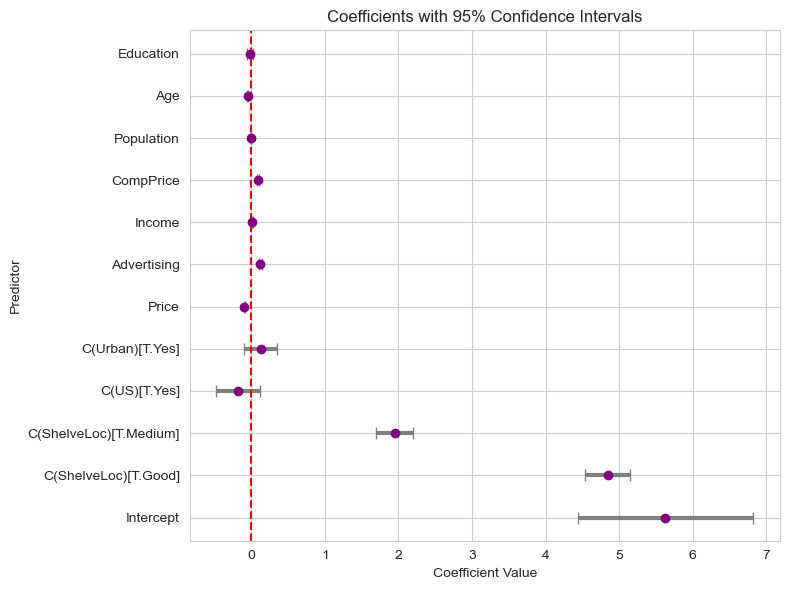

```python
# Getting coefficients and CI
coefs = model_full.params
conf = model_full.conf_int()
conf['coef'] = coefs
conf.columns = ['CI_lower', 'CI_upper', 'coef']
conf = conf.reset_index().rename(columns={'index':'Variable'})

# Plot
plt.figure(figsize=(8,6))
plt.errorbar(x=conf['coef'], y=conf['Variable'],
             xerr=[conf['coef'] - conf['CI_lower'], conf['CI_upper'] - conf['coef']],
             fmt='o', color='purple', ecolor='grey', elinewidth=3, capsize=4)
plt.axvline(x=0, color='red', linestyle='--')  # zero-effect line
plt.title('Coefficients with 95% Confidence Intervals')
plt.xlabel('Coefficient Value')
plt.ylabel('Predictor')
plt.tight_layout()
plt.show()
```

```python
# Is there multi-colinearity? Computing VIF (Variance Inflation Factor) to test multi-colinearity

X = df[['Price','Advertising','Income','CompPrice','Population','Age','Education']]
X = sm.add_constant(X)
vif = pd.DataFrame()
vif['Variable'] = X.columns
vif['VIF'] = [variance_inflation_factor(X.values, i) for i in range(X.shape[1])]
print(vif)
```

```
      Variable         VIF
0        const  133.588758
1        Price    1.532236
2  Advertising    1.087370
3       Income    1.013808
4    CompPrice    1.547467
5   Population    1.102918
6          Age    1.015699
7    Education    1.014531
```

**Key Takeaways from ANOVA**

All the hypotheses are rejected except Community Education and Population. Meaning Shelf Postion and the other predictors except Community Education and Population have a significant effect on the Sales - corroborated by the F value, p value and the Confidence Intervals.

All predictors have VIF values below 2 (except the intercept), indicating low multicollinearity. This suggests that the effects of individual variables on Sales are reliably estimated and the ANOVA results are stable.

### More ANOVA

This is time we are trying to see if there are any significant predictor behind Advertisement cost. The aim is to combine the finding with the sales predictors and develop a deeper understanding of the car seat sales pattern.

```python
model_adv = ols('Advertising ~ C(ShelveLoc) + C(Urban) + C(US) + Price + Income + CompPrice + Population + Age + Education', data=df).fit()
anova_adv = sm.stats.anova_lm(model_adv, typ=2)
print(anova_adv)
```

```
                   sum_sq     df           F        PR(>F)
C(ShelveLoc)    29.404633    2.0    0.686652  5.038736e-01
C(Urban)        12.900353    1.0    0.602493  4.381049e-01
C(US)         7704.174570    1.0  359.812889  3.961210e-57
Price            6.258658    1.0    0.292302  5.890617e-01
Income           0.025239    1.0    0.001179  9.726292e-01
CompPrice       10.127070    1.0    0.472971  4.920377e-01
Population     899.673656    1.0   42.018022  2.773264e-10
Age              0.083910    1.0    0.003919  9.501165e-01
Education       46.041417    1.0    2.150301  1.433582e-01
Residual      8243.471260  385.0         NaN           NaN
```

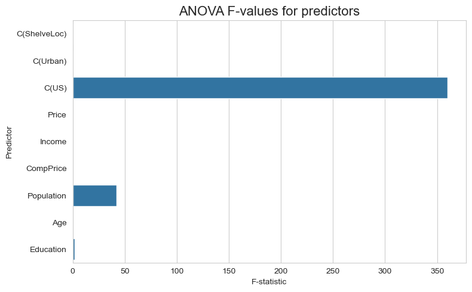

```python
# Preparing ANOVA table for visualisation (excluding residuals)
anova_plot_adv = anova_adv.reset_index().rename(columns={'index':'Variable'})
anova_plot_adv = anova_plot_adv[anova_plot_adv['Variable'] != 'Residual']  # drop residual

plt.figure(figsize=(8,5))
sns.barplot(x='F', y='Variable', data=anova_plot_adv)
plt.title('ANOVA F-values for predictors', fontsize=16)
plt.xlabel('F-statistic')
plt.ylabel('Predictor')
plt.tight_layout()
plt.show()
```

```python
print(model_adv.conf_int(alpha=0.05))  # 95% CI
```

```
                               0          1
Intercept              -9.263941   1.505133
C(ShelveLoc)[T.Good]   -0.840255   1.904764
C(ShelveLoc)[T.Medium] -0.460929   1.807036
C(Urban)[T.Yes]        -0.611025   1.408174
C(US)[T.Yes]            8.396676  10.338626
Price                  -0.017308   0.030437
Income                 -0.016225   0.016802
CompPrice              -0.049983   0.024078
Population              0.007268   0.013596
Age                    -0.029524   0.027702
Education              -0.044794   0.307663
```

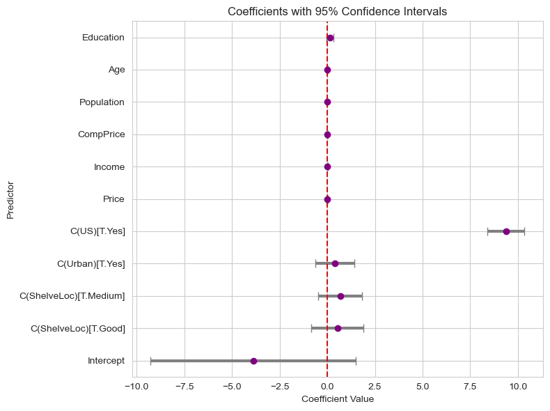

```python
# Getting coefficients and CI
coefs = model_adv.params
conf = model_adv.conf_int()
conf['coef'] = coefs
conf.columns = ['CI_lower', 'CI_upper', 'coef']
conf = conf.reset_index().rename(columns={'index':'Variable'})

# Plot
plt.figure(figsize=(8,6))
plt.errorbar(x=conf['coef'], y=conf['Variable'],
             xerr=[conf['coef'] - conf['CI_lower'], conf['CI_upper'] - conf['coef']],
             fmt='o', color='purple', ecolor='grey', elinewidth=3, capsize=4)
plt.axvline(x=0, color='red', linestyle='--')  # zero-effect line
plt.title('Coefficients with 95% Confidence Intervals')
plt.xlabel('Coefficient Value')
plt.ylabel('Predictor')
plt.tight_layout()
plt.show()
```

## Step 4: Statistical Tests

In the previous section we looked into the paire-wise correlation between the variables. With ANOVA we also tried finding any significant predictors to Sales volume. In this section we will conduct independent two sample t-tests to gain further insight into the store's location, area demography and product attributes for a better market understanding. The questions can be:

**Question 1:** Do Urban stores have high income customers as expected?

$H_0: \mu1 = \mu2$ ;There is no income difference of the community whether the store is in Urban or in Rural area $H_A: \mu1 > \mu2$ ;The community income level in Urban is higher in the Urban than in the Rural area

**Question 2:** Do we have high sales in the Urban area?

$H_0: \mu1 = \mu2$ ;Sales is not different between Urban and Rural area $H_A: \mu1 > \mu2$ ;Sales is higher in the Urban than in the Rural area

**Question 3:** Do the car seats cost higher in the Urban area? $H_0: \mu1 = \mu2$ ;Car Seats cost the same in Urban and Rural area $H_A: \mu1 > \mu2$ ;Car Seats cost is higher in Urban than in Rural area

**Question 4:** Do we have higher revenue in the Urban area? $H_0: \mu1 = \mu2 $ ;Revenue from selling Car Seats is the same in the Rural and the Urban area $H_A: \mu1 > \mu2 $ ;Revenue from selling Car Seats is higher in the Urban than in the Rural area

**Question 5:** Is Price different than Competitor's Price? $H_0: \mu1 = \mu2 $ ;Price is not different than Competitor's Price $H_A: \mu1 < \mu2 $ ;Price is lower than Competitor's Price

```python
# Question 1: Do Urban stores have high income customers as expected?
# High Income (≥ median) & Urban stores

urban_income = df[df['Urban'] == 'Yes']['Income']
rural_income = df[df['Urban'] == 'No']['Income']
urban_income.describe(), rural_income.describe()
```

```
(count    278.000000
 mean      69.417266
 std       27.361175
 min       21.000000
 25%       44.000000
 50%       70.000000
 75%       91.000000
 max      120.000000
 Name: Income, dtype: float64,
 count    118.000000
 mean      67.016949
 std       29.680919
 min       21.000000
 25%       40.250000
 50%       67.000000
 75%       90.000000
 max      120.000000
 Name: Income, dtype: float64)
```

```python
# The variance is different. So running Welch’s t-test
t_stat, p_two_tailed = ttest_ind(urban_income, rural_income, equal_var=False)

# If group1 mean > group2 mean
if t_stat > 0:
    p_one_tailed = p_two_tailed / 2
else:
    p_one_tailed = 1 - (p_two_tailed / 2)

print("t-statistic:", t_stat)
print("one-tailed p-value:", p_one_tailed)
```

```
t-statistic: 0.7530959128914143
one-tailed p-value: 0.22612741218121446
```

The one-tailed Welch’s t-test shows that Urban stores do not have significantly higher community income than Rural stores (t = 0.75, p = 0.23). Therefore, we cannot conclude that Urban locations serve higher-income communities.

```python
# Question 2: Do we have high sales in the Urban area?

urban_sales = df[df['Urban'] == 'Yes']['Sales']
rural_sales = df[df['Urban'] == 'No']['Sales']
urban_sales.describe(), rural_sales.describe()
```

```
(count    278.000000
 mean       7.503525
 std        2.825597
 min        0.370000
 25%        5.482500
 50%        7.435000
 75%        9.317500
 max       16.270000
 Name: Sales, dtype: float64,
 count    118.000000
 mean       7.563559
 std        2.805846
 min        0.000000
 25%        5.440000
 50%        7.670000
 75%        9.335000
 max       14.900000
 Name: Sales, dtype: float64)
```

```python
# The variance is slightly different. So running Welch’s t-test
t_stat, p_two_tailed = ttest_ind(urban_sales, rural_sales, equal_var=False)

# If group1 mean > group2 mean
if t_stat > 0:
    p_one_tailed = p_two_tailed / 2
else:
    p_one_tailed = 1 - (p_two_tailed / 2)

print("t-statistic:", t_stat)
print("one-tailed p-value:", p_one_tailed)
```

```
t-statistic: -0.19432917997828536
one-tailed p-value: 0.5769520875285206
```

The t-statistic is negative, meaning the mean of Urban sales is actually slightly lower than Rural sales. But with p value greater than 0.05, there is no statistically significant evidence that Urban stores have higher sales than Rural stores. The observed difference in means could easily be due to random variation.

```python
# Question 3: Do the car seats cost higher in the Urban area?

urban_price = df[df['Urban'] == 'Yes']['Price']
rural_price = df[df['Urban'] == 'No']['Price']
urban_price.describe(), rural_price.describe()
```

```
(count    278.000000
 mean     116.392086
 std       24.052910
 min       24.000000
 25%      101.000000
 50%      118.000000
 75%      131.000000
 max      191.000000
 Name: Price, dtype: float64,
 count    118.000000
 mean     114.076271
 std       23.037004
 min       49.000000
 25%       97.000000
 50%      112.500000
 75%      128.000000
 max      185.000000
 Name: Price, dtype: float64)
```

```python
# The variance is slightly different. So running Welch’s t-test
t_stat, p_two_tailed = ttest_ind(urban_price, rural_price, equal_var=False)

# If group1 mean > group2 mean
if t_stat > 0:
    p_one_tailed = p_two_tailed / 2
else:
    p_one_tailed = 1 - (p_two_tailed / 2)

print("t-statistic:", t_stat)
print("one-tailed p-value:", p_one_tailed)
```

```
t-statistic: 0.902896470486678
one-tailed p-value: 0.1837636235623616
```

There is no statistically significant evidence that Urban stores charge higher prices than Rural stores. The observed difference could easily be due to random variation.

```python
# Question 4: Do we have higher revenue in the Urban area?

df['Revenue'] = df['Sales']*df['Price'] # creating a new column Revenue = Sales*Price

urban_revenue = df[df['Urban'] == 'Yes']['Revenue']
rural_revenue = df[df['Urban'] == 'No']['Revenue']
urban_revenue.describe(), rural_revenue.describe()
```

```
(count     278.000000
 mean      844.916331
 std       309.174515
 min        70.670000
 25%       622.260000
 50%       824.300000
 75%      1025.797500
 max      1794.260000
 Name: Revenue, dtype: float64,
 count     118.000000
 mean      830.341017
 std       284.685306
 min         0.000000
 25%       652.540000
 50%       844.645000
 75%       994.532500
 max      1586.230000
 Name: Revenue, dtype: float64)
```

```python
# The variance is slightly different. So running Welch’s t-test
t_stat, p_two_tailed = ttest_ind(urban_revenue, rural_revenue, equal_var=False)

# If group1 mean > group2 mean
if t_stat > 0:
    p_one_tailed = p_two_tailed / 2
else:
    p_one_tailed = 1 - (p_two_tailed / 2)


print("t-statistic:", t_stat)
print("one-tailed p-value:", p_one_tailed)
```

```
t-statistic: 0.4540016771435566
one-tailed p-value: 0.3251204602387639
```

```python
# Question 5: Is Price different than Competitor's Price?

t_stat, p_val = ttest_rel(df['Price'], df['CompPrice'])

if t_stat < 0:
    p_one_tailed = p_val / 2
else:
    p_one_tailed = 1 - (p_val / 2)

print("t-statistic:", t_stat)
print("one-tailed p-value:", p_one_tailed)
```

```
t-statistic: -9.499824842111856
one-tailed p-value: 1.0309998015761473e-19
```

We reject the null hypothesis. Our Car Seat price is lower compared to the Competitor's Price.

## Step 5: Regression Analysis

We are going to perform a multiple regression analysis where Sales is the dependent variable and independent variables will include all variables proven statistically significant predictors in the ANOVA analysis earlier.

$Sales = \alpha + \beta_1*Shelf Position + \beta_2*Price + \beta_3*Advertising Cost+ \beta_4*Income \beta_5*Competitor Price \beta_6*Age $

```python
model = ols('Sales ~ C(ShelveLoc) + Price + Advertising + Income + CompPrice + Age', data=df).fit()
```

```python
model.summary()
```

OLS Regression Results

| Dep. Variable: | Sales | R-squared: | 0.871 |
| --- | --- | --- | --- |
| Model: | OLS | Adj. R-squared: | 0.868 |
| Method: | Least Squares | F-statistic: | 373.3 |
| Date: | Thu, 11 Dec 2025 | Prob (F-statistic): | 4.92e-168 |
| Time: | 16:26:59 | Log-Likelihood: | -566.36 |
| No. Observations: | 396 | AIC: | 1149. |
| Df Residuals: | 388 | BIC: | 1181. |
| Df Model: | 7 |  |  |
| Covariance Type: | nonrobust |  |  |

|  | coef | std err | t | P>\|t\| | [0.025 | 0.975] |
| --- | --- | --- | --- | --- | --- | --- |
| Intercept | 5.4845 | 0.507 | 10.818 | 0.000 | 4.488 | 6.481 |
| C(ShelveLoc)[T.Good] | 4.8256 | 0.154 | 31.416 | 0.000 | 4.524 | 5.128 |
| C(ShelveLoc)[T.Medium] | 1.9390 | 0.127 | 15.288 | 0.000 | 1.690 | 2.188 |
| Price | -0.0952 | 0.003 | -35.524 | 0.000 | -0.100 | -0.090 |
| Advertising | 0.1150 | 0.008 | 14.788 | 0.000 | 0.100 | 0.130 |
| Income | 0.0156 | 0.002 | 8.476 | 0.000 | 0.012 | 0.019 |
| CompPrice | 0.0926 | 0.004 | 22.382 | 0.000 | 0.084 | 0.101 |
| Age | -0.0461 | 0.003 | -14.363 | 0.000 | -0.052 | -0.040 |

| Omnibus: | 0.729 | Durbin-Watson: | 1.989 |
| --- | --- | --- | --- |
| Prob(Omnibus): | 0.694 | Jarque-Bera (JB): | 0.781 |
| Skew: | 0.102 | Prob(JB): | 0.677 |
| Kurtosis: | 2.923 | Cond. No. | 1.91e+03 |

Notes:  
[1] Standard Errors assume that the covariance matrix of the errors is correctly specified.  
[2] The condition number is large, 1.91e+03. This might indicate that there are  
strong multicollinearity or other numerical problems.

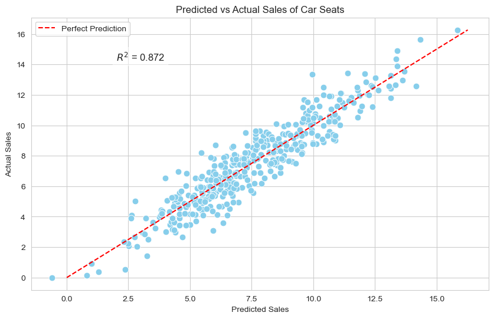

```python
import matplotlib.pyplot as plt
import seaborn as sns

# Predicted values
df['Predicted_Sales'] = model_full.fittedvalues

# R-squared
r2 = model_full.rsquared

# Plot
plt.figure(figsize=(10,6))
sns.scatterplot(x='Predicted_Sales', y='Sales', data=df, color='skyblue', s=60)
plt.plot([df['Sales'].min(), df['Sales'].max()],
         [df['Sales'].min(), df['Sales'].max()],
         color='red', linestyle='--', label='Perfect Prediction')
plt.text(df['Sales'].min()+2, df['Sales'].max()-2, f'$R^2$ = {r2:.3f}',
         fontsize=12, bbox=dict(facecolor='white', alpha=0.5))
plt.title('Predicted vs Actual Sales of Car Seats')
plt.xlabel('Predicted Sales')
plt.ylabel('Actual Sales')
plt.grid(True)
plt.legend()
plt.show()
```

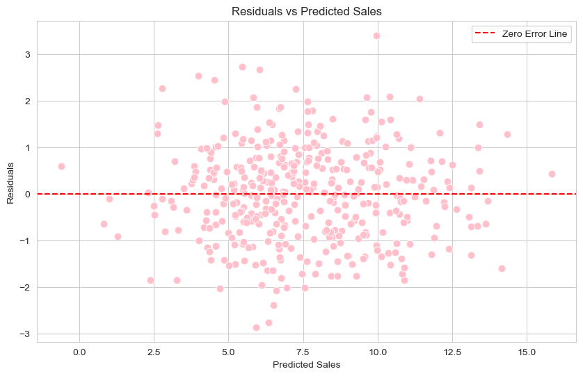

```python
# Calculate residuals
df['Residuals'] = df['Sales'] - df['Predicted_Sales']

# Residuals vs Predicted plot
plt.figure(figsize=(10,6))
sns.scatterplot(x='Predicted_Sales', y='Residuals', data=df, color='pink', s=60)
plt.axhline(0, color='red', linestyle='--', label='Zero Error Line')
plt.title('Residuals vs Predicted Sales')
plt.xlabel('Predicted Sales')
plt.ylabel('Residuals')
plt.grid(True)
plt.legend()
plt.show()
```

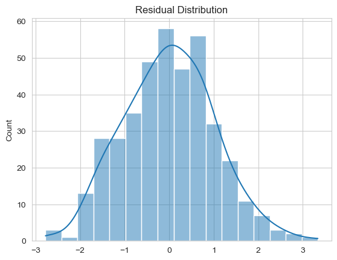

```python
# checking residual distribution
resid = model.resid
sns.histplot(resid, kde=True)
plt.title("Residual Distribution")
plt.show()
```

**Key Takeaways**

The OLS regression explains 87% of the variance in Sales (R² = 0.871).

Shelf location, Price, Advertising, Income, CompPrice, and Age are all statistically significant predictors (p < 0.001).

Positive coefficients for Good/Medium shelf location, Advertising, Income, and CompPrice indicate higher Sales, while Price and Age negatively impact Sales.

## Step 6: Summary of Interpretation and Insights

The multiple regression model confirms these patterns: Shelf Location, Price, Advertising, Income, Competitor Price, and Age all significantly influence Sales. Good shelving positions, higher advertising spend, higher competitor prices, and higher community income increase Sales, while higher Price and older population reduce it. Multicollinearity is mild. Residual diagnostics suggest that regression assumptions hold reasonably well.

Overall, the analysis highlights that **shelf positioning**, **pricing strategy**, **local demography** and **promotional spending** are key drivers of car seat sales. These insights provide actionable guidance for optimizing store layout, pricing, and promotional strategies to increase revenue.

### Recommendations

**1. Shelf Placement Optimization**

**Observation:** Shelf Location is the strongest categorical predictor of Sales. **Recommendation:** Prioritize placing car seats in “Good” shelving locations to maximize visibility and sales. Medium locations are also significantly better than “Bad,” so improving shelf quality can yield incremental gains.

**2. Pricing Strategy**

**Observation:** Price negatively affects sales, showing customer sensitivity, while Competitor Price positively affects demand. **Recommendation:** Consider pricing competitively but avoid underpricing too much — ensure that your price positioning considers competitor pricing. Dynamic pricing or localized pricing strategies may help maximize revenue.

**3. Advertising Allocation**

**Observation:** Advertising increases Sales and is correlated with Population and US locations, but correlation with Sales is modest. **Recommendation:** Allocate advertising strategically, focusing on areas where the impact on sales is expected to be higher (e.g., high-population areas, locations with “Good” shelf placement).

**4. Target High-Income Areas**

**Observation:** Income positively affects Sales. **Recommendation:** Tailor promotions or premium product options in higher-income regions to capture higher demand.

**5. Consider Demographic Effects**

**Observation:** Age has a negative association with Sales. **Recommendation:** Focus marketing and placement strategies in areas with younger populations, or introduce complementary products for older demographics if targeting them.

**6. Monitor Outliers and High-Leverage Locations**

**Observation:** Some locations have unusually high Sales, Advertising, or Population. **Recommendation:** Identify these outliers to understand best practices or special circumstances — e.g., high-performing stores might indicate successful layouts, promotions, or market characteristics worth replicating elsewhere.

**7. Continuous Monitoring**

Implement a dashboard to track Sales, Advertising, and Price effects over time and by location. This allows quick adjustment to marketing, pricing, and inventory strategies.

## Acknowledgement

AI tools were used to support understanding and learning of relevant programming (e.g. chart creation in bokeh, using grid, troubleshooting etc) and data analysis techniques.